# Tutorial 8: Data Mining Basics

Due by 1 April 2022, 8:00 AM

## Submission Instructions

- Select `output: html_document`.
- Include all code chunks, so include `echo=TRUE` in all chunks.
- Replace the placeholder text, “Type your answer here.”, with your own.
- Submit *only* the required question for grading (Part 2: Submission). You can delete everything else for that submission. Remember to include any `library('package_name')` statements that you’ll need to run your code and future reproduction.
- Rename your R Markdown file `T[X]_[MatricNumber].rmd`, and the output will automatically be `T[X]_[MatricNumber].html`.
- Submit your both R Markdown file (.rmd) and HTML (.html) to Luminus for tutorial assignments (upload to Luminus under the correct Submission Folder). We shall do the same for practical exam.
- **It is important to be able to code and produce your Rmarkdown output file *independently*.** You are responsible for de-bugging and programming in the practical exam.

```r
# load required packages
library(dplyr)
library(tidyr)
library(car) # for linearHypothesis()
library(ggplot2) # optional. we expect you to know base graphics, but allow ggplot if you find it easier
library(psych) # for pairs.panels()
library(factoextra) # for fviz_cluster()
library(wooldridge)
```

## Part One: Lab Session Completion and Discussion

### Question 1

- Dataset required: `whiskies.csv`

This will be an exploratory question using k-means clustering to examine a dataset of Whiskey Taste Indicators. The dataset can be obtained from https://outreach.mathstat.strath.ac.uk/outreach/nessie/nessie_whisky.html.

It consists of 86 (Single-Malt) Whiskies that are rated from 0-4 on 12 different taste categories: `Body`, `Sweetness`, `Smoky`, `Medicinal`, `Tobacco`, `Honey`, `Spicy`, `Winey`, `Nutty`, `Malty`, `Fruity`, `Floral`.

Here’s what the dataset looks like:

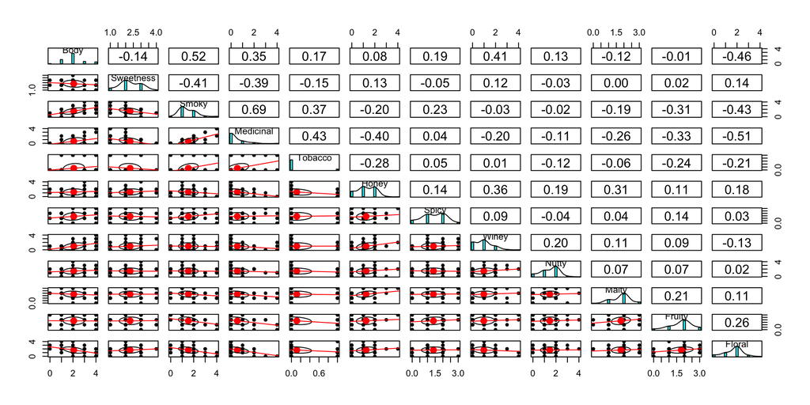

```r
wh = read.csv('whiskies.csv', header=T)

# Selecting out the independent variables "X".
whX <- wh %>% select(c("Body", "Sweetness", "Smoky", "Medicinal", "Tobacco", "Honey", "Spicy", "Winey", "Nutty", "Malty", "Fruity", "Floral"))

# using pairs.panel() to look at the data
pairs.panels(whX, lm=T)
```

The main purpose of this question is to try clustering a real dataset, and try to interpret the clusters via looking at the cluster centers (in the dimensions of the independent variables), and generating “profiles” for each cluster.

Q1a)

Let’s try clustering the different whiskies based on their taste profile. First, let’s use the Elbow method to pick the best number of clusters.

Using the code discussed in lecture, calculate the Within-Cluster Sum of Squares from k=2 to k=20 clusters using `whX`, and plot the Within-Cluster Sum of Squares against number of clusters.

*Note*, normally if the variables are on very different scales, we should standardize the variables (to have mean 0 and sd 1). But in this case, all the variables are on the same scale; they’re all 0-4. So even if they may have different means and SDs, it’s ok to NOT scale the variables. Just run kmeans on `whX`.

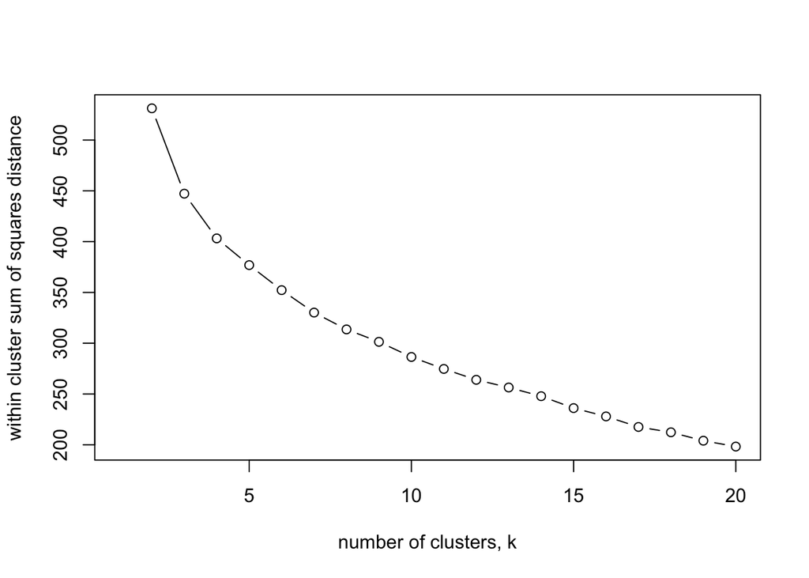

```r
# type your code here
set.seed(1)
wss1 = rep(NA, 20)
for (k in c(2:20)){
  wss1[k] = kmeans(whX, k, nstart=10)$tot.withinss
}

plot(wss1,
     type="b",
     xlab="number of clusters, k",
     ylab="within cluster sum of squares distance")
```

Q1b)

From the plot, it does not seem like there is a clear Elbow. The Within-Cluster Sum of Squares seem to keep decreasing, and there doesn’t seem to be a clear stopping point. This may happen in real datasets (and this is a real dataset), so we may have to use our own judgment to decide on the number of clusters.

Ok, let’s say our local business partner applies his expert intuition, and tells us that `k=3` seems a good starting point.

Because the output of k-means depends upon the random initialization, we need to set the seed of the random number generator, so that all of us (students+TAs+instructors) can get the same results.

**Run the following code the line before your k-means code.**

```
set.seed(1)
... = kmeans(...)
```

Then use the `fviz_cluster()` function from the `factoextra` package to plot the results of this clustering.

What do you notice from the graph? Discuss this with your TA and fellow students. (Recall that the graph dimensions will be along the top two principal components.)

Again, no answers needed here, except the graph. Discussion points here are that there seems to be three clearly separated clusters: one (in the graph above, Cluster 1) that’s much higher on PC1 than the rest (i.e., on the right of the graph). The other two (Clusters 2 and 3) are on the left side of the graph, buth they are separeted by PC2, such that Cluster 2 is higher on PC2 and Cluster 3 is lower on PC2.

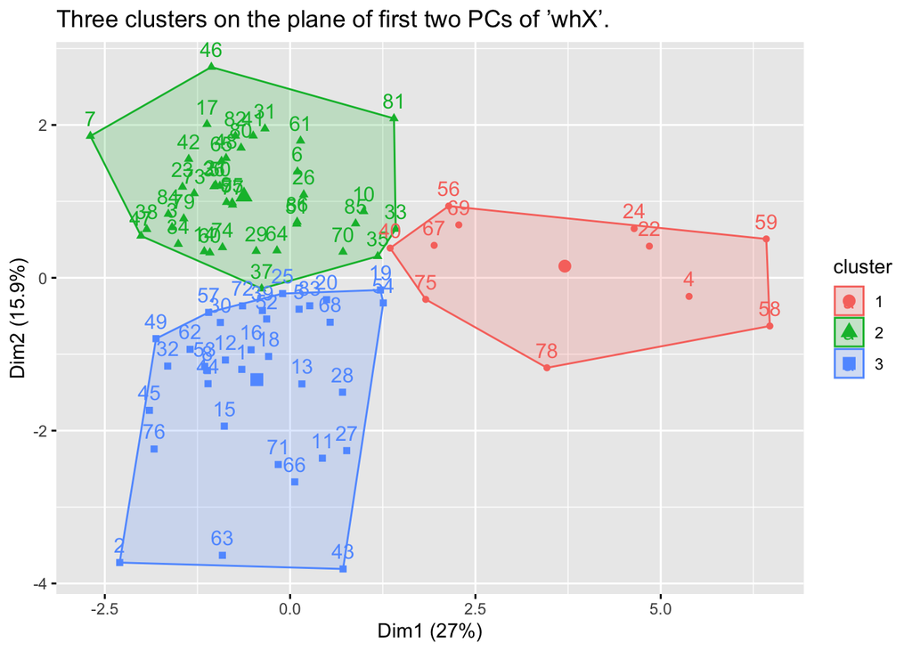

```r
# type your code here
set.seed(1)
km_whX <- kmeans(whX, centers = 3)

fviz_cluster(km_whX,
             data=whX,
             main = "Three clusters on the plane of first two PCs of ’whX’.")
```

Q1c)

Ok, let’s use `<kmeans_object_name> $center` (where `<kmeans_object_name>` is the name of the kmeans model you fit above) to extract the centers of the 3 clusters.

Try to interpret the clusters. I’ll provide you with one observation, please generate at least four more.

- I notice that Cluster 1 has the highest Body compared to Clusters 2 and 3.

After generating several of these observations, try to summarize your observations into a Taste Profile for each Cluster. FOR EXAMPLE, is Cluster 1 high in Smoky, Tobacco-y, Spicyness?

If your client really likes very rich, Smoky, Medicinal Whiskies, which cluster would you recommend to him? (e.g., if this were a real client, you could go back and look at the Distilleries in `wh` and generate a list of those in the same cluster.)

```r
# type your code here
km_whX$center
```

```
##       Body Sweetness    Smoky Medicinal    Tobacco     Honey    Spicy     Winey
## 1 2.909091  1.545455 2.909091 2.7272727 0.45454545 0.4545455 1.454545 0.5454545
## 2 1.487805  2.463415 1.121951 0.2682927 0.07317073 0.9268293 1.146341 0.5121951
## 3 2.500000  2.323529 1.588235 0.1764706 0.05882353 1.8823529 1.647059 1.6764706
##      Nutty    Malty   Fruity    Floral
## 1 1.545455 1.454545 1.181818 0.5454545
## 2 1.146341 1.658537 1.878049 2.0000000
## 3 1.823529 2.088235 1.911765 1.7058824
```